# Pulse Nutrient Model for Phytoplankton

The aim of the model is to study how temperature changes affect size dynamics of phytoplankton populations in a pulse nutrient environment. We have done this by combining the temperature and size model used in “Reuman, D. C., Holt, R. D. and Yvon-Durocher, G. (2014), A metabolic perspective on competition and body size reductions with warming. J Anim Ecol, 83: 59-69. doi:10.1111/1365-2656.12064” with the pulse nurtrient and size model used in “Litchman E, Klausmeier CA, Yoshiyama K. Contrasting size evolution in marine and freshwater diatoms. Proc Natl Acad Sci U S A. 2009;106(8):2665-70.”

```r
library(deSolve)
library(Rcpp)
library(parallel)
library(CmodelRHS2)
library(microbenchmark)
```

Initiliasing the model parameters. Converts cell sizes, temperature and metaparms to dynamical model parameters Qmin, Qmax etc.

```r
rm(list=ls())  # remove any prior variable
k <- 8.6173324e-05    # Global constant: Boltzmann's constant
dynamic_parms <- function(s, metaparms){
  with(as.list(metaparms),{
    Qmin   <- kQmin*(s^eQmin*exp(EQmin*(T-T0)/(k*T*T0)))
    Qmax   <- kQmax*s^eQmax*exp(EQmax*(T-T0)/(k*T*T0))
    Vmax   <- kVmax*s^eVmax*exp((EVmax*(T-T0))/(k*T*T0))
    mu_max <- kmu_max*(exp((Emu_max*(T-T0))/(k*T*T0))*(s^emu_max))
    mu_inf <- (mu_max*Vmax*Qmax)/((Vmax*(Qmax-Qmin))-(mu_max*Qmin*(Qmax-Qmin)))
    m      <- km*(s^em)*exp((Em*(T-T0))/(k*T*T0))
    H_up   <- (kH_up*s^eH_up*exp(EH_up*(T-T0)/(k*T*T0)))/T
    return(c(Qmin=Qmin, Qmax=Qmax, Vmax=Vmax, mu_inf=mu_inf, H_up=H_up, m=m))
  })
}
```

## Phytoplankton growth model

ModelRHS is the func argument to LSODA that contains five differntial equations used to derive the changes in population, interal nutrient quota and external nutrient concentration. parms is not used in this case and is merely there to satisfy the requirment of lsoda, instead parms is split into d_parms_i & j and is passed as additional arguments, y is a list containing the current state of the system.

The ModelRHS function below is provided for reference, & can be used in case of compatability issues with the Rcpp code.

```r
ModelRHS <- function(time, y, parms, d_parms_i, d_parms_j){
  dN_dt_i <- (y['N_i']*(d_parms_i['mu_inf']*(1-(d_parms_i['Qmin']/y['Q_i']))-d_parms_i['m']))
  dN_dt_j <- (y['N_j']*(d_parms_j['mu_inf']*(1-(d_parms_j['Qmin']/y['Q_j']))-d_parms_j['m']))
  dQ_dt_i <- ((d_parms_i['Vmax']*((d_parms_i['Qmax']-y['Q_i'])/(d_parms_i['Qmax']-d_parms_i['Qmin']))
                  *(y['R']/(y['R']+d_parms_i['H_up'])))
                 -(d_parms_i['mu_inf']*(1-(d_parms_i['Qmin']/y['Q_i']))*y['Q_i']))
  dQ_dt_j <- ((d_parms_j['Vmax']*((d_parms_j['Qmax']-y['Q_j'])/(d_parms_j['Qmax']-d_parms_j['Qmin']))
                  *(y['R']/(y['R']+d_parms_j['H_up'])))
                -(d_parms_j['mu_inf']*(1-(d_parms_j['Qmin']/y['Q_j']))*y['Q_j']))

  dR_dt   <- (-(d_parms_i['Vmax']*((d_parms_i['Qmax']-y['Q_i'])/(d_parms_i['Qmax']-d_parms_i['Qmin']))
                *((y['R']*y['N_i'])/(y['R']+d_parms_i['H_up'])))
              -(d_parms_j['Vmax']*((d_parms_j['Qmax']-y['Q_j'])/(d_parms_j['Qmax']-d_parms_j['Qmin']))
                *((y['R']*y['N_j'])/(y['R']+d_parms_j['H_up']))))
  res <- c(dN_dt_i, dN_dt_j, dQ_dt_i, dQ_dt_j, dR_dt)
  return(list(res))
}
```

structure of d_parms_(i/j):  
[0] - Qmin  
[1] - Qmax  
[2] - Vmax  
[3] - mu_inf  
[4] - H_up  
[5] - m

structure of y:  
[0] - N_i  
[1] - N_j  
[2] - Q_i  
[3] - Q_j  
[4] - R  
Rcpp::NumericVector is special variables created by Rcpp not available in normal C++ code, mimics the R vector variable The Rcpp code is callable below, but future functions use the same function contained in a package form.

```cpp
#include <Rcpp.h>
using namespace Rcpp;
// [[Rcpp::export]]
SEXP rcpp_ModelRHS_local(SEXP timesexp, SEXP ysexp, SEXP parmssexp, SEXP d_parms_isexp, SEXP d_parms_jsexp){
    Rcpp::NumericVector y(ysexp);
    Rcpp::NumericVector d_parms_i(d_parms_isexp);
    Rcpp::NumericVector d_parms_j(d_parms_jsexp);

    double N_i = (y[0]*(d_parms_i[3]*(1-(d_parms_i[0]/y[2]))-d_parms_i[5]));
    double N_j = (y[1]*(d_parms_j[3]*(1-(d_parms_j[0]/y[3]))-d_parms_j[5]));

    double Q_i = ((d_parms_i[2]*((d_parms_i[1]-y[2])/(d_parms_i[1]-d_parms_i[0]))
                   *(y[4]/(y[4]+d_parms_i[4])))
                  -(d_parms_i[3]*(1-(d_parms_i[0]/y[2]))*y[2]));
    double Q_j = ((d_parms_j[2]*((d_parms_j[1]-y[3])/(d_parms_j[1]-d_parms_j[0]))
                   *(y[4]/(y[4]+d_parms_j[4])))
                -(d_parms_j[3]*(1-(d_parms_j[0]/y[3]))*y[3]));

    double R   = (-(d_parms_i[2]*((d_parms_i[1]-y[2])/(d_parms_i[1]-d_parms_i[0]))
                    *((y[4]*y[0])/(y[4]+d_parms_i[4])))
                 -(d_parms_j[2]*((d_parms_j[1]-y[3])/(d_parms_j[1]-d_parms_j[0]))
                  *((y[4]*y[1])/(y[4]+d_parms_j[4]))));

    return Rcpp::List::create(Rcpp::NumericVector::create(Rcpp::Named("N_i", N_i),
                                                          Rcpp::Named("N_j", N_j),
                                                          Rcpp::Named("Q_i", Q_i),
                                                          Rcpp::Named("Q_j", Q_j),
                                                          Rcpp::Named("R", R)));
}
```

## Pulse nutrient model

During Pulse you get mixing occur according to the model from Litchman et al (2009): nutrient concentration post mix = (fraction of water not mixed * nutrient concentration pre mix) + nurtrient influx during mix popultaion density post mix = fraction of water not mixed * population desntiy pre mix

```r
Pulse <- function(fraction_replaced, R_in, last_res){
  Ni_post  <- (1-fraction_replaced)*last_res[2]
  Nj_post  <- (1-fraction_replaced)*last_res[3]
  R_post   <- ((1-fraction_replaced)*last_res[6])+(fraction_replaced*R_in)
  post_mix <- c(time=last_res[1], N_i=Ni_post, N_j=Nj_post, Q_i=last_res[4], Q_j=last_res[5], R=R_post)
  return(post_mix)
}
```

[output not shown]

Defining the function that runs the entire simulation

```r
# Runs the entire simulation once for a pair of sizes and a single pulse period
Model_sim <- function(metaparms, size_of_i, size_of_j, ini_cond, fraction_replaced, R_in,
                      pulse_period, output_folder_name, out_times) {
  dir_i <- paste(getwd(),output_folder_name, "/", sep="")
  dir.create(file.path(dir_i), showWarnings=FALSE, recursive=TRUE)
  setwd(file.path(dir_i))
  # dir   <- paste("si=", size_of_i, ", sj=", size_of_j, sep="")  # use this code to place in seperate folders dictated by their sizes
  # dir.create(file.path(dir), showWarnings = FALSE, recursive = TRUE)
  # setwd(file.path(dir))
  end_time  <- tail(out_times, n=1)
  d_parms_i <- dynamic_parms(size_of_i, metaparms)
  d_parms_j <- dynamic_parms(size_of_j, metaparms)
  ini_cond["Q_i"] <- median(d_parms_i["Qmax"], d_parms_i["Qmin"])  # to make sure that Q_i & Q_j are within the boundaries of Qmax & Qmin.
  ini_cond["Q_j"] <- median(d_parms_j["Qmax"], d_parms_j["Qmin"])  # Uses a value in between the two.
#  initialisation with the first run
  times     <- c(0, subset(out_times, out_times > 0 & out_times < pulse_period), pulse_period)  # only the beginning, end and all stated out times
  results   <- lsoda(y=ini_cond, times=times, func=CmodelRHS2::rcpp_ModelRHS, parms=0, d_parms_i=d_parms_i, d_parms_j=d_parms_j)
  if(length(results[results[,"time"] %in% out_times, ]) != 0){  # determines if there are any values present in out times
    temp_res  <- results[-nrow(results), ]
    total     <- temp_res[temp_res[,"time"] %in% out_times, ] # stores only the results that are within out_times
    sum_total <- total
  } else {
    sum_total <- NULL  # if there are not values stores a NULL value as placeholder
  }
  time      <- tail(times, n=1)

# Loop that runs through the rest of the times after initial first run
  while(time < end_time){
    times   <- c(time, subset(out_times, out_times > time & out_times < (time+pulse_period)), (time+pulse_period))
    results[nrow(results),] <- Pulse(fraction_replaced, R_in, tail(results, n=1))
    results <- lsoda(y=results[nrow(results),-1], times=times, func=CmodelRHS2::rcpp_ModelRHS, parms=0, d_parms_i=d_parms_i, d_parms_j=d_parms_j)
    if(length(results[results[,"time"] %in% out_times, ]) != 0){
      temp_res  <- results
      total     <- temp_res[temp_res[,"time"] %in% out_times, ]
      sum_total <- rbind(sum_total, total)
    }
    time    <- tail(times, n=1)
  }
  sum_total <- sum_total[which(!duplicated(sum_total[ ,1], fromLast = TRUE)), ]  # gets rid of all results pre-pulse keeps only post-pulse in
  write.csv(sum_total, file=paste("Results, si=", size_of_i, ", sj=", size_of_j, ", pulse=", pulse_period, ".csv", sep=""))
  return(sum_total)
}
```

Two variants of plot function Plot_pop for only population plots and Plot_all for population, internal nutrient quota & external nutrient quota

```r
Plot_pop <- function(total, size_of_i, size_of_j, pulse_period, plot_start, plot_end){
  jpeg (paste("si=", size_of_i, ", sj=", size_of_j,", pulse period=", pulse_period,".jpeg", sep=""), width=9600, height=5400, pointsize=80)

  if (plot_end == 0){
    par(mfrow = c(1,2))
    plot(total[,1], total[,2], type="l", main=paste("Population Density of i, pulse period=(",pulse_period,")"),
         xlab="time(days)", ylab="Number of cells L-1")
    plot(total[,1], total[,3], type="l", main=paste("Population Density of j, pulse period=(",pulse_period,")"),
         xlab="time(days)", ylab="Number of cells L-1")
  } else {
    par(mfrow = c(1,2))
    plot(total[plot_start:plot_end,1], total[plot_start:plot_end,2], type="l",
         main=paste("Population Density of i, pulse period=(",pulse_period,")"), xlab="time(days)", ylab="Number of cells L-1")
    plot(total[plot_start:plot_end,1], total[plot_start:plot_end,3], type="l",
         main=paste("Population Densiaty of j, pulse period=(",pulse_period,")"), xlab="time(days)", ylab="Number of cells L-1")
  }
  dev.off()
}
Plot_all <- function(total, size_of_i, size_of_j, pulse_period, plot_start, plot_end){
  jpeg (paste("si=", size_of_i, ", sj=", size_of_j,", pulse period=", pulse_period,".jpeg", sep=""), width=9600, height=5400, pointsize=80)
  if (plot_end == 0){  # determines the range of data plotted based on plot_start & plot_end
    par(mfrow=c(2,3))
    plot(total[,1], total[,2], type="l", main=paste("Population Density of i, pulse period=(",pulse_period,")"),
         xlab="time(days)", ylab="Number of cells L-1")
    plot(total[,1], total[,4], type="l", main=paste("Internal Cellular Nutrient Quota of i, pulse period=(",pulse_period,")"),
         xlab="time(days)", ylab="mu mol nutrient L-1")
    plot(total[,1], total[,6], type="l", main=paste("External Concentration of Nutrient, pulse period=(",pulse_period,")"),
         xlab="time(days)", ylab="mu mol L-1")
    plot(total[,1], total[,3], type="l", main=paste("Population Density of j, pulse period=(",pulse_period,")"),
         xlab="time(days)", ylab="Number of cells L-1")
    plot(total[,1], total[,5], type="l", main=paste("Internal Cellular Nutrient Quota of j, pulse period=(",pulse_period,")"),
         xlab="time(days)", ylab="mu mol nutrient L-1")
  } else {
    par(mfrow=c(2,3))
    plot(total[plot_start:plot_end,1], total[plot_start:plot_end,2], type="l",
         main=paste("Population Density of i, pulse period=(",pulse_period,")"), xlab="time(days)", ylab="Number of cells L-1")
    plot(total[plot_start:plot_end,1], total[plot_start:plot_end,4], type="l",
         main=paste("Internal Cellular Nutrient Quota of i, pulse period=(",pulse_period,")"), xlab="time(days)", ylab="mu mol nutrient L-1")
    plot(total[plot_start:plot_end,1], total[plot_start:plot_end,6], type="l",
         main=paste("External Concentration of Nutrient, pulse period=(",pulse_period,")"), xlab="time(days)", ylab="mu mol L-1")
    plot(total[plot_start:plot_end,1], total[plot_start:plot_end,3], type="l",
         main=paste("Population Density of j, pulse period=(",pulse_period,")"), xlab="time(days)", ylab="Number of cells L-1")
    plot(total[plot_start:plot_end,1], total[plot_start:plot_end,5], type="l",
         main=paste("Internal Cellular Nutrient Quota of j, pulse period=(",pulse_period,")"), xlab="time(days)", ylab="mu mol nutrient L-1")
  }
  dev.off()
}
```

Initialising the default variable values

```r
# Note: keep these the same and then modify them by replacing specific variable values in later code
# This is a vector of parameters that describe how cell size and temp affect the dynamical model parameters
metaparms <- c(T0      = 293.15,           # for 20 degrees C
               T       = 293.15,
               EQmin   = -0.230,           # from line 115 suppmat Reuman et al 2013
               eQmin   = 0.84,             # line 119 reuman et al 2013 supp mat
               kQmin   = 1e-09,            # table 2 supp mat reuman et al 2013 (originally from edwards et al 2012)
               eQmax   = 0.809,            # table 2 supp mat reuman et al 2013 (originally from montagnes & franklin 2001)
               kQmax   = 10^-8.03,         # table 2 supp mat reuman et al 2013
               EQmax   = 0,
               EVmax   = 0.456,            # line 104 supp mat reuman et al 2013
               eVmax   = 0.82,             # table 2 supp mat reuman et al 2013
               kVmax   = 1e-08,            # table 2 supp mat reuman et al 2013 (originally from edwards et al 2012)
               emu_max = -0.28,            # table 2 supp mat reuman et al 2013
               kmu_max = 10^0.65,          # table 2 supp mat reuman et al 2013
               Emu_max = 0.474,            # line 235 of rueman et al 2013
               eH_up   = (1/3),            # table 2 supp mat reuman et al 2013
               kH_up   = 10^-0.61,         # table 2 supp mat reuman et al 2013
               EH_up   = 0.277,            # line 99 supp mat reuman et al 2013
               km      = 0.01,             # one of the options from fig 2 supp mat
               em      = 0,                # 0 for cell size independant sinking
               Em      = 0.1781)           # fig 2 supp mat

# model variables
size_of_i         <- 1e03
size_of_j         <- 1e06
ini_cond <- c(N_i  = 1000,   # initial population size of i
              N_j  = 1000,
              Q_i  = 0,      # only a place holder, Q_i & Q_j is calculated later inside Model_sim
              Q_j  = 0,
              R    = 40)     # initial external nutrient concentration
# variables for mixing event
fraction_replaced  <- 0.3  # under methods in Litchman et al (2009) varies from 0.2-0.5, used values of 0.1, 0.3, 0.5 in models
R_in               <- 40   # from litchman et al 2009 under methods, can vary from 0.05-0.95, used 40 in their model
# variables for simulation time in days
pulse_period       <- 14
# plot range
plot_start         <- 0
plot_end           <- 0  # (set plot_end=0 for whole plot)
# extras
output_folder_name <- "tester"  # use to create folder for graph output
```

## Model Simulation to look for coexistence between species i and j

Looking for coexistence, by running through a range of sizes for species j and looking for increases in population density

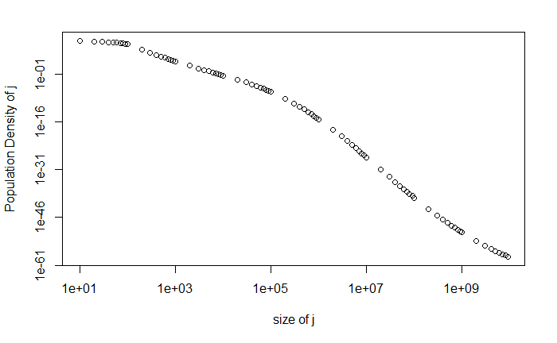

```r
cl <- makeCluster(detectCores()-1)
clusterExport(cl, c("k", "dynamic_parms", "Pulse", "lsoda", "rcpp_ModelRHS"))
pulse_period <- 15
size_of_i <- 1e2
# creates a series of sizes for species j to then compare against size if species i
numbers <- NULL
num <- c(1e1, 1e2, 1e3, 1e4, 1e5, 1e6, 1e7, 1e8, 1e9)
for (num in num){
  numbers <- rbind(numbers, c(1, 2, 3, 4, 5, 6, 7, 8, 9)*num)
}
size_of_j <- numbers
out_times <- 5000
Totals <- parLapply(cl, size_of_j, fun=Model_sim, metaparms=metaparms, size_of_i=size_of_i, ini_cond=ini_cond,
                    fraction_replaced=fraction_replaced, R_in=R_in, pulse_period=pulse_period,
                    output_folder_name=output_folder_name, out_times=out_times)
all_Nj <- NULL
for (i in 1:length(size_of_j)){
all_Nj <- rbind(all_Nj, Totals[[i]]["N_j"])
}
plot(size_of_j , all_Nj, xlab="size of j", ylab="Population Density of j", log="xy")
```

## Benchmarking ODE solving speed between C++ and native R code

Benchmarked to compare the C++ & R variation of the model only lsoda function

```r
times     <- seq(0, 1000, 1)
size_of_i <- 1e2
size_of_j <- 1e4
d_parms_i <- dynamic_parms(size_of_i, metaparms)
d_parms_j <- dynamic_parms(size_of_j, metaparms)
ini_cond["Q_i"] <- median(d_parms_i["Qmax"], d_parms_i["Qmin"])
ini_cond["Q_j"] <- median(d_parms_j["Qmax"], d_parms_j["Qmin"])
bench <- microbenchmark(lsoda(y=ini_cond, times=times, func=ModelRHS, parms=0, d_parms_i=d_parms_i, d_parms_j=d_parms_j),
                        lsoda(y=ini_cond, times=times, func=CmodelRHS2::rcpp_ModelRHS, parms=0, d_parms_i=d_parms_i, d_parms_j=d_parms_j),
                        times=10)
summary(bench)
```

| expr | min | lq | mean | median | uq | max | neval |
| --- | --- | --- | --- | --- | --- | --- | --- |
| lsoda(y = ini_cond, times = times, func = ModelRHS, parms = 0, d_parms_i = d_parms_i, d_parms_j = d_parms_j) | 82.09460 | 82.30177 | 87.75091 | 87.18519 | 90.51233 | 99.68502 | 10 |
| lsoda(y = ini_cond, times = times, func = CmodelRHS2::rcpp_ModelRHS, parms = 0, d_parms_i = d_parms_i, d_parms_j = d_parms_j) | 11.24519 | 11.61392 | 12.74578 | 12.64447 | 13.93465 | 14.23002 | 10 |

```r
# CmodelRHS2::rcpp_ModelRHS(time = time, y=ini_cond, parms=0, d_parms_i=d_parms_i, d_parms_j=d_parms_j)
```

## Testing parallelisation of code

Below are a few chunks of code that was used to run the code in parallel.

Benchamark of running simulation in parallel splitting up the pulse periods in this case

```r
cl <- makeCluster(detectCores())
clusterExport(cl, c("k", "dynamic_parms", "Pulse", "lsoda", "rcpp_ModelRHS"))
pulse_period <- c(14, 30, 50)
out_times <- seq(0,5000,1)
pulse_period <- as.matrix(pulse_period)
bench <- microbenchmark(parLapply(cl, pulse_period, fun=Model_sim, metaparms=metaparms, size_of_i=size_of_i, size_of_j=size_of_j,
                                  ini_cond=ini_cond, fraction_replaced=fraction_replaced, R_in=R_in,
                                  output_folder_name=output_folder_name, out_times=out_times),
                        apply(pulse_period, 1, FUN=Model_sim, metaparms=metaparms, size_of_i=size_of_i, size_of_j=size_of_j,
                              ini_cond=ini_cond, fraction_replaced=fraction_replaced, R_in=R_in,
                              output_folder_name=output_folder_name, out_times=out_times),
                        times = 5)
summary(bench)
```

| expr | min | lq | mean | median | uq | max | neval |
| --- | --- | --- | --- | --- | --- | --- | --- |
| parLapply(cl, pulse_period, fun = Model_sim, metaparms = metaparms, size_of_i = size_of_i, size_of_j = size_of_j, ini_cond = ini_cond, fraction_replaced = fraction_replaced, R_in = R_in, output_folder… | 1.823753 | 1.908307 | 2.147258 | 2.117439 | 2.433204 | 2.453586 | 5 |
| apply(pulse_period, 1, FUN = Model_sim, metaparms = metaparms, size_of_i = size_of_i, size_of_j = size_of_j, ini_cond = ini_cond, fraction_replaced = fraction_replaced, R_in = R_in, output_folder_name… | 2.655995 | 2.686394 | 3.247902 | 3.050319 | 3.446767 | 4.400033 | 5 |

Test for parallel processing using built in parallel package function parLapply

```r
Rprof("Rprof.out", memory.profiling=TRUE)
cl <- makeCluster(detectCores()-1)  # creates a cluster defined by the number of cores avaialbe, leaving one free for user to control computer
clusterExport(cl, c("k", "dynamic_parms", "Pulse", "lsoda", "rcpp_ModelRHS"))  # exports all the necessary functions to the cluster
pulse_period <- c(14, 30, 50)
out_times <- seq(0,1000,1)
# parLapply is a fucntion from the inbuilt parallel package, it runs  Model_sim function with the vector of pulse_period provided, in this case
# it simultaneously runs three iterations of Model_sim each with difffernt pulse_period and stores results in Totals
Totals <- parLapply(cl, pulse_period, fun=Model_sim, metaparms=metaparms, size_of_i=size_of_i, size_of_j=size_of_j, ini_cond=ini_cond,
                    fraction_replaced=fraction_replaced, R_in=R_in, output_folder_name=output_folder_name, out_times=out_times)
Plot_pop(Totals[[1]], size_of_i, size_of_j, pulse_period[1], plot_start, plot_end)  # Totals[[1]] is for pulse_period 14
```

```r
Plot_pop(Totals[[2]], size_of_i, size_of_j, pulse_period[2], plot_start, plot_end)  # Totals[[2]] is for pulse_period 30
```

```r
Plot_pop(Totals[[3]], size_of_i, size_of_j, pulse_period[3], plot_start, plot_end)
```

```r
Rprof(NULL)
summaryRprof("Rprof.out", memory = "both")
```

|  | self.time | self.pct | total.time | total.pct | mem.total |
| --- | --- | --- | --- | --- | --- |
| ".External" | 2.94 | 50.17 | 2.94 | 50.17 | 0.1 |
| "socketConnection" | 1.14 | 19.45 | 1.14 | 19.45 | 0.1 |
| "unserialize" | 0.88 | 15.02 | 0.88 | 15.02 | 0.6 |
| "title" | 0.30 | 5.12 | 0.30 | 5.12 | 0.1 |
| "axis" | 0.18 | 3.07 | 0.18 | 3.07 | 0.5 |
| ".External2" | 0.10 | 1.71 | 0.10 | 1.71 | 0.6 |
| "plot.xy" | 0.08 | 1.37 | 0.08 | 1.37 | 0.4 |
| "serialize" | 0.08 | 1.37 | 0.08 | 1.37 | 4.0 |
| "cb$putcode" | 0.04 | 0.68 | 0.04 | 0.68 | 3.7 |
| "lapply" | 0.02 | 0.34 | 0.90 | 15.36 | 0.8 |

[output cut: 5 more lines]

|  | total.time | total.pct | mem.total | self.time | self.pct |
| --- | --- | --- | --- | --- | --- |
| "Plot_pop" | 3.68 | 62.80 | 5.6 | 0.00 | 0.00 |
| ".External" | 2.94 | 50.17 | 0.1 | 2.94 | 50.17 |
| "dev.off" | 2.14 | 36.52 | 0.0 | 0.00 | 0.00 |
| "makeCluster" | 1.18 | 20.14 | 0.3 | 0.00 | 0.00 |
| "makePSOCKcluster" | 1.18 | 20.14 | 0.3 | 0.00 | 0.00 |
| "newPSOCKnode" | 1.18 | 20.14 | 0.3 | 0.00 | 0.00 |
| "socketConnection" | 1.14 | 19.45 | 0.1 | 1.14 | 19.45 |
| "lapply" | 0.90 | 15.36 | 0.8 | 0.02 | 0.34 |
| "unserialize" | 0.88 | 15.02 | 0.6 | 0.88 | 15.02 |
| "FUN" | 0.88 | 15.02 | 0.6 | 0.00 | 0.00 |

[output cut: 62 more lines]

```
$`sample.interval`
[1] 0.02

$sampling.time
[1] 5.86
```